```python
import numpy as np
import pandas as pd
import matplotlib as map
import matplotlib.pyplot as plt
import scipy as sc
import statistics as stat
from scipy.stats import binom
```

# 1. Dongkyu and Chulung are working on an algorithmic trading project for the TEK club. By using their project, Dongkyu assumes that their project has 60% chance of making a profitable trade (success) and 40% chance of making an unprofitable trade (failure) in the stock market. Now, you should calculate the probability of achieving a specific outcome over a series of 20 trades in a single day. What is the probability of making 15 profitable trades out of 20 with a given successful rate?

```python
# n = number of trials
# success rate: p
# value of interest: x
n = 20
p = 0.6
x = 15

# calculation of binomial probability
binomial_pmf_single=binom.pmf(x,n,p)
binomial_pmf_single
```

```
0.07464701952887112
```

```python
# calculate the entire probability distribution
k=np.arange(0,n+1)
k
```

```
array([ 0,  1,  2,  3,  4,  5,  6,  7,  8,  9, 10, 11, 12, 13, 14, 15, 16,
       17, 18, 19, 20])
```

```python
# With k, array of all possible values, we can calculate their probability in mass
binomial_pmf_all=binom.pmf(k,n,p)
binomial_pmf_all
```

```
array([1.09951163e-08, 3.29853488e-07, 4.70041221e-06, 4.23037099e-05,
       2.69686150e-04, 1.29449352e-03, 4.85435071e-03, 1.45630521e-02,
       3.54974396e-02, 7.09948791e-02, 1.17141551e-01, 1.59738478e-01,
       1.79705788e-01, 1.65882266e-01, 1.24411699e-01, 7.46470195e-02,
       3.49907904e-02, 1.23496907e-02, 3.08742268e-03, 4.87487792e-04,
       3.65615844e-05])
```

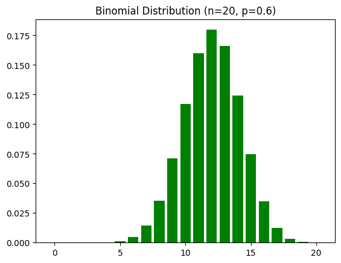

```python
# plt.bar function creates bar function.
# The function indicates the following:
# x=k, y=binomial_pmf_all, color='blue'
plt.bar(k, binomial_pmf_all, color='green')

# plt.title function add the title of the plot
plt.title(f"Binomial Distribution (n={n}, p={p})")
plt.show()
```

# 2. Jiwon, Juah, and Hyeonji take a multiple-choice exam together. Each question has two possible answers (True or False). As they work together to solve each question, their probability of guessing the correct answer is 70%. If they guess randomly on 30 questions and successfully get 20 of them correct, what is the binomial probability distribution that models this scenario?

```python
# n = number of trials
# success rate: p
# value of interest: x
n = 30
p = 0.7
x = 20

# calculation of binomial probability
binomial_pmf_single=binom.pmf(x,n,p)
binomial_pmf_single
```

```
0.1415617010620011
```

```python
# calculate the entire probability distribution
k=np.arange(0,n+1)
k
```

```
array([ 0,  1,  2,  3,  4,  5,  6,  7,  8,  9, 10, 11, 12, 13, 14, 15, 16,
       17, 18, 19, 20, 21, 22, 23, 24, 25, 26, 27, 28, 29, 30])
```

```python
# With k, array of all possible values, we can calculate their probability in mass
binomial_pmf_all=binom.pmf(k,n,p)
binomial_pmf_all
```

```
array([2.05891132e-16, 1.44123792e-14, 4.87618831e-13, 1.06192545e-11,
       1.67253259e-10, 2.02933954e-09, 1.97296900e-08, 1.57837520e-07,
       1.05882670e-06, 6.03923375e-06, 2.95922454e-05, 1.25542859e-04,
       4.63811119e-04, 1.49846669e-03, 4.24565563e-03, 1.05669651e-02,
       2.31152362e-02, 4.44175127e-02, 7.48517343e-02, 1.10307819e-01,
       1.41561701e-01, 1.57290779e-01, 1.50141198e-01, 1.21853726e-01,
       8.29282302e-02, 4.64398089e-02, 2.08383758e-02, 7.20338916e-03,
       1.80084729e-03, 2.89791518e-04, 2.25393403e-05])
```

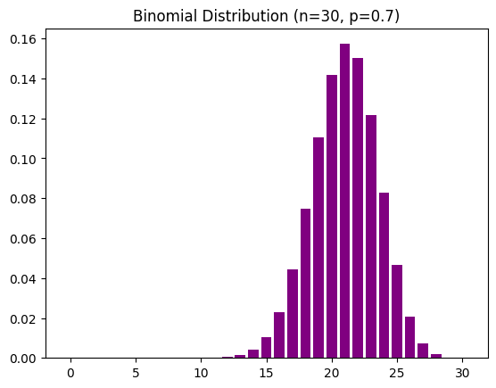

```python
# plt.bar function creates bar function.
# The function indicates the following:
# x=k, y=binomial_pmf_all, color='blue'
plt.bar(k, binomial_pmf_all, color='purple')

# plt.title function add the title of the plot
plt.title(f"Binomial Distribution (n={n}, p={p})")
plt.show()
```

# 3. RH- is a rare blood type that only 1% of people in the world have. Suppose you are developing a diagnostic test for detecting this blood type which has an accuracy rate of 95%. This means that there is a 95% chance that the test will correctly detect it, and if a person does not have RH-, then there is a chance the test will correctly identify them as RH+. If you use this diagnostic test on a random sample of 300 people and identify that 290 people are successfully tested, what is the binomial probability distribution of this scenario?

```python
# n = number of trials
# success rate: p
# value of interest: x
n = 300
p = 0.95
x = 290

binomial_pmf_single=binom.pmf(x,n,p)
binomial_pmf_single
```

```
0.047331712613707166
```

```python
# calculate the entire probability distribution
k=np.arange(0,n+1)
k
```

[output not shown]

```python
# With k, array of all possible values, we can calculate their probability in mass
binomial_pmf_all=binom.pmf(k,n,p)
binomial_pmf_all
```

[output not shown]

[output cut: 21 more lines]

[output not shown]

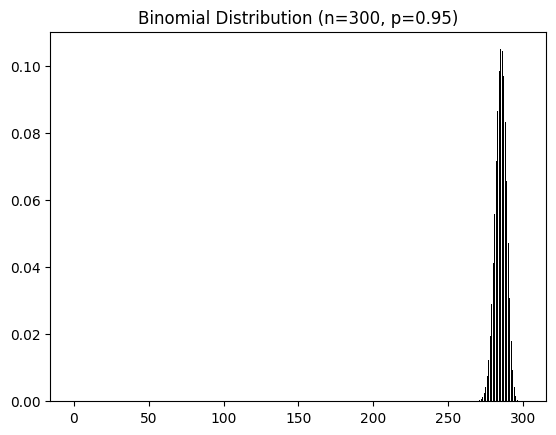

```python
# plt.bar function creates bar function.
# The function indicates the following:
# x=k, y=binomial_pmf_all, color='blue'
plt.bar(k, binomial_pmf_all, color='black')

# plt.title function add the title of the plot
plt.title(f"Binomial Distribution (n={n}, p={p})")
plt.show()
```